# Methods Writeup

Author

Travis Keep (Advisor: Dr. Seals)

Published

November 10, 2024

While normal linear regression has many useful applications, it does not accurately explain all models. For instance, normal linear regression does not always provide good models where the dependent variable has a definite minimum and maximum. Test scores are a good example, where scores typically fall between 0 and 100. In this paper, we discuss a new method, beta regression, and how it often does a better job of explaining data with a definite minimum and maximum, and we discuss how beta regression can be used in R.

First we discuss general linear regression. In general linear regression, the dependent variable is modeled as a linear combination of the regressors in the model plus some constant. For example $\hat{y}=\beta_0 + \beta_1 x_1 + \beta_2 x_2 + \beta_3 x_3 + \cdots$. The $\beta_i$’s are chosen to minimise the the Sum of Squares error which is

$$SSE = \sum_{i=1}^{n} (y_i - \hat{y}_i)^2$$
The interpretation of the $\beta_i$ is as follows. If the regressosr $x_i$ increases by 1, then $\hat{y}$ increases by $\beta_i$. [1].

An ANOVA table can test the significance of a general linear regression model.

$$\begin{align}
SST &= \sum_{i=1}^{n} (y_i - \bar{y})^2 \\
SSR &= \sum_{i=1}^{n} (\hat{y_i} - \bar{y})^2 \\
SSE &= \sum_{i=1}^{n} (y_i - \hat{y_i})^2
\end{align}$$
Where SST is the total variance of Y; SSR is the variance explained by the model. SSE is the variance not explained by the model. [1].

ANOVA table

| Sum of Squares | degrees of freedom | Mean Square | F |
| --- | --- | --- | --- |
| SSR | p | $MSR=\frac{SSR}{p}$ |  |
| SSE | n - p - 1 | $MSE=\frac{SSE}{n-p-1}$ | $\frac{MSR}{MSE}$ |
| SST | n - 1 |  |  |

$p$ is the number of betas excluding $\beta_0$.

if $F > F_\alpha(p, n-p-1)$ then the model is significant. [1].

## Why General Linear Regression is not Always Suitable

General linear regression assumes that the error terms $\epsilon = y_i - \hat{y_i}$ follow a normal distribution with constant variance across all the i’s. When the dependent variable has a definite minumum and maximum such as a ratio or percentage, this assumption that general linear regression makes does not hold. The variance of the error terms is not constant, but becomes less when the dependent variable gets close to its minimum or maximum. Sometimes we must assume that the dependent variable follows a beta distribution instead of a normal distribution.

## Beta Distribution

The beta distribution is for a random variable that falls on the open set (0, 1). Note that it is possible to scale any random variable with a definite minimum and maximum to this interval. Below is the PDF for the beta distribution.

$$f(y) = \begin{cases}
\frac{y^{\alpha-1}(1-y)^{\beta-1}}{B(\alpha,\beta)}, & 0 \le y \le 1 \\
0, & \text{elsewhere}
\end{cases}$$
Where $B(\alpha,\beta) = \int_0^1 y^{\alpha-1}(1-y)^{\beta-1} \ dy = \frac{\Gamma(\alpha) \Gamma(\beta)}{\Gamma(\alpha+\beta)}.$

$\alpha$ and $\beta$ are the shape variables where $\alpha > 0 \quad \beta > 0$. [2]

$$E[Y] = \mu = \frac{\alpha}{\alpha+\beta} \ \ \ \text{and} \ \ \ V[Y] = \sigma^2 = \frac{\alpha\beta}{(\alpha+\beta)^2(\alpha+\beta+1)}$$
[2]

For beta regression it is useful to introduce the following,

$$\begin{align}
\mu &= \frac{\alpha}{\alpha+\beta} \\
\phi &= \alpha + \beta
\end{align}$$
$\mu$ is the mean of the beta regression while the higher the $\phi$ the less the variance or the less spread out the PDF function is. [3]

We can rewrite the beta distribution PDF function in terms of $\mu$ and $\phi$.

$$f(y; \mu, \phi) = \frac{\Gamma(\phi)}{\Gamma(\mu \phi) \Gamma((1 - \mu)\phi)} y^{\mu\phi - 1}(1 - y)^{(1 - \mu)\phi - 1}, \quad 0 < y < 1$$
Where:
- **(μ)** is the mean, **(ϕ)** is the precision (inverse of the variance), **(Γ)** is the gamma function.

$$\text{Var}(Y) = \frac{\mu(1 - \mu)}{1 + \phi}$$
When $\mu$ is near the extremes, 0 or 1, variance drops. [3]

## Beta Regression

With beta regression, we first scale the dependent variable so that it falls on the (0, 1) interval. We then apply the logit function to the dependent variable.

$$logit(p) = log \left(\frac{p}{1-p}\right)$$
The logit function transforms the input value, which is between 0 and 1, to all the real values. The result of the logit function can be anywhere between $-\infty$ and $+\infty$.

Beta regression aims to create more accurate models when the dependent variable falls within a certain range such as between 0 and 1. Beta regression assumes that at a given point, the dependent variable follows a beta distribution instead of a normal distribution [4].

We apply the logit function to the dependent variable, $\mu_i$, and fit a linear model to that. Unlike linear regression, we also apply the natural logarithm function to phi and fit a linear model to that. [5]. So we have

$$logit(\mu_i) = x_i\beta$$
$$ln(\phi_i) = -w_i\delta$$

[5]. Note that $w_i$ is often some subset of $x_i$. The minus sign is in the second equation so that larger coefficients in $\delta$ mean a larger variance. [5]. We find the coefficients of $\beta$ and $\delta$ by maximizing the log likelihood function which is in terms of $\beta$ and $\delta$. R supports three methods for finding the $\beta_i$ and $\delta_i$, ML which is just standard maximum likelihood. BC, which is maximum likelihood with bias correction, and BR which is maximum likelihood with bias reduction [4].

Note that $\phi$ can be modeled as being constant throughout or it can be modeled as being dependent on certain regressors [5].

With $\beta$ we can predict $\mu$ as follows:

$$\mu = \frac{e^{x \beta}}{e^{x \beta} + 1}$$

Like in linear regression, the $\beta_i$ have a definite interpretation. If $x_i$ increases by 1 with all other regressors remaining the same, the odds of $\mu$ multiply by $e^{b_i}$. Where the odds of $\mu$ are $\frac{\mu}{1-\mu}$ [3].

## ReadingSkills Dataset

Here are the description of the columns

| Name | Type | Description |
| --- | --- | --- |
| accuracy | numeric | Reading score with max of 0.99 |
| dyslexia | character | Yes for dyslexic, No for not dyslexic |
| iq | numeric | Non verbal intelligence quotient transform to z score |
| accuracy1 | numeric | same as accuracy but score goes up to 1.0 |

```r
library(betareg)
library(dplyr)
library(magrittr)
data("ReadingSkills")

dyslexia <- ReadingSkills %>% filter(dyslexia == "yes")
normal <- ReadingSkills %>% filter(dyslexia == "no")
n <- (ReadingSkills %>% dim)[1]
ndyslexia <- (dyslexia %>% dim)[1]
nnormal <- (normal %>% dim)[1]
iq_stats <- ReadingSkills %>% summarize(min(iq), median(iq), max(iq))
iq_dyslexia_stats <- dyslexia %>% summarize(min(iq), median(iq), max(iq))
iq_normal_stats <- normal %>% summarize(min(iq), median(iq), max(iq))
score_stats <- ReadingSkills %>% summarize(min(accuracy1), median(accuracy1), max(accuracy1))
score_dyslexia_stats <- dyslexia %>% summarize(min(accuracy1), median(accuracy1), max(accuracy1))
score_normal_stats <- normal %>% summarize(min(accuracy1), median(accuracy1), max(accuracy1))
```

| Table 1: Student ReadingSkills data stratified by dyslexia | Table 1: Student ReadingSkills data stratified by dyslexia | Table 1: Student ReadingSkills data stratified by dyslexia | Table 1: Student ReadingSkills data stratified by dyslexia | Table 1: Student ReadingSkills data stratified by dyslexia |  |  |  |  |  |
| --- | --- | --- | --- | --- | --- | --- | --- | --- | --- |
|  |  |  |  |  | Student Characteristic |  | Total (n=44) | Dyslexia (n=19) | Normal (n=25) |
| IQ (Z-Score) | min | -1.745 | -1.745 | -0.914 |  |  |  |  |  |
|  | median | -0.1225 | -0.795 | 0.59 |  |  |  |  |  |
|  | max | 1.856 | 1.223 | 1.856 |  |  |  |  |  |
| Reading Score | min | 0.45932 | 0.45932 | 0.64662 |  |  |  |  |  |
|  | median | 0.70593 | 0.60916 | 1 |  |  |  |  |  |
|  | max | 1 | 0.70281 | 1 |  |  |  |  |  |

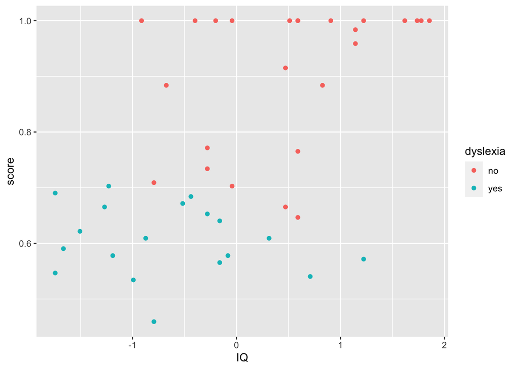

```r
library(ggplot2)
coords <- aes(x=iq, y=accuracy1)
ggplot(ReadingSkills, coords) + geom_point(aes(color=dyslexia)) + labs(x="IQ", y="score")
```

## Analysis

In this section, we do beta regression analysis on the ReadingSkills data set. First, we add a numeric equivalent for dyslexia, dcode, to our dataset. For “no”, we code -0.0; for “yes” we code 1.0. We use the full model for $\mu$ (dcode, iq, and dcode:iq), but we model $\phi$ as being constant. This raises our pseudo R^2 from 0.5089, when we used the full model for $\phi$, to 0.6067. We use “BC” (Bias Correction) which is the same as maximumm likelihood except it corrects for bias. To visualise the regression, we split the results into dyslexic children and normal children [6].

In addition to the beta regression, we also do general linear regression using the logit link function. logit has the special property of transforming test scores falling on the interval (0, 1) to values falling on the set $\mathbb{R}$. When predicting, test scores with this model, we apply the inverse logit function to map from the $\mathbb{R}$ back to the interval (0, 1) [7].

$$\begin{align}
logit(p) &= log \left( \frac{p}{1-p} \right) \\
invlogit(p) &= \frac{e^p}{e^p + 1}
\end{align}$$

```r
ReadingSkillsModel <- ReadingSkills %>% mutate(dcode=ifelse(dyslexia == "no", 0.0, 1.0))

model <- betareg(accuracy ~ dcode*iq, data=ReadingSkillsModel, type="BC")
summary(model)
```

```
Call:
betareg(formula = accuracy ~ dcode * iq, data = ReadingSkillsModel, type = "BC")

Quantile residuals:
    Min      1Q  Median      3Q     Max
-2.2624 -0.4148  0.0724  0.4798  1.6967

Coefficients (mean model with logit link):
            Estimate Std. Error z value Pr(>|z|)
(Intercept)   2.2778     0.2185  10.423  < 2e-16 ***
dcode        -1.9203     0.2822  -6.804 1.02e-11 ***
iq            0.3727     0.2206   1.690   0.0911 .
dcode:iq     -0.4299     0.2818  -1.525   0.1272

Phi coefficients (precision model with identity link):
      Estimate Std. Error z value Pr(>|z|)
(phi)    9.520      2.096   4.543 5.55e-06 ***
---
Signif. codes:  0 '***' 0.001 '**' 0.01 '*' 0.05 '.' 0.1 ' ' 1

Type of estimator: BC (bias-corrected)
Log-likelihood: 51.09 on 5 Df
Pseudo R-squared: 0.6067
Number of iterations: 19 (BFGS) + 2 (Fisher scoring)
```

**Diagnostic** **Plots**

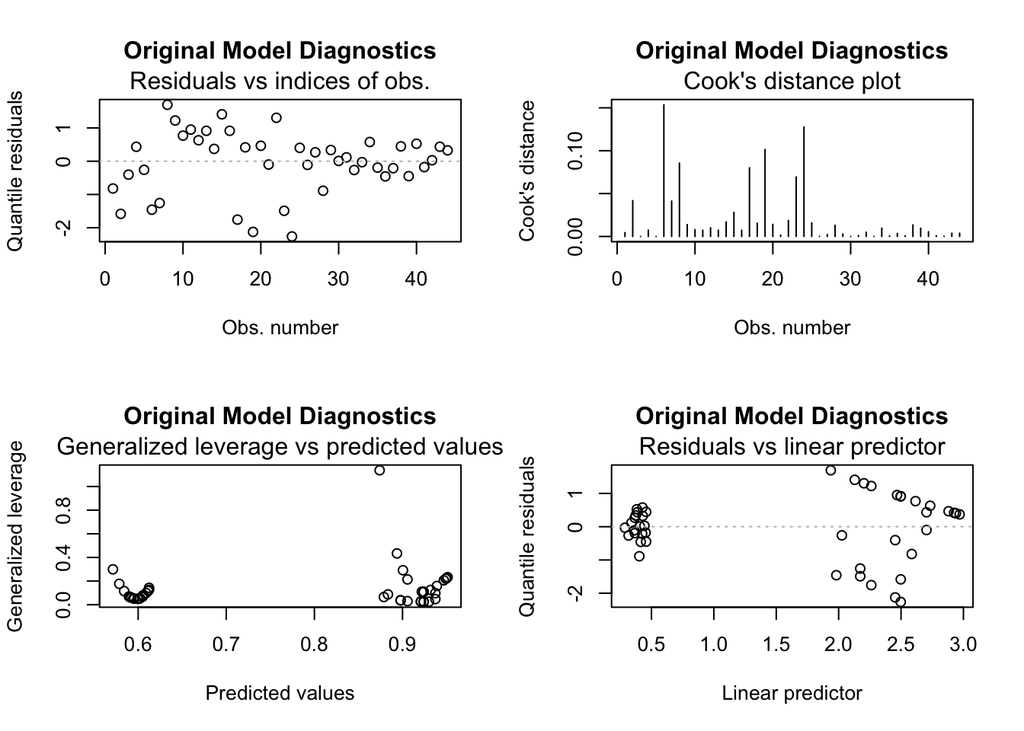

```r
par(mfrow = c(2, 2))
plot(model, main = "Original Model Diagnostics")
```

```r
#Identify influential points
cooks_dist <- cooks.distance(model)
leverage <- hatvalues(model)
residuals <- residuals(model, type = "pearson")

# Set thresholds
cooks_threshold <- 4 / nrow(ReadingSkillsModel)
leverage_threshold <- 2 * (length(coef(model)) / nrow(ReadingSkillsModel))
residual_threshold <- 3


#Identify extreme points
extreme_points <- which(cooks_dist > cooks_threshold |
                        leverage > leverage_threshold |
                        abs(residuals) > residual_threshold)
```

Number of extreme points found: 4

```r
ReadingSkillsModel.cleaned <- ReadingSkillsModel[-extreme_points, ]

model <- betareg(accuracy ~ dcode*iq, data=ReadingSkillsModel.cleaned, type="BC")
summary(model)
```

```
Call:
betareg(formula = accuracy ~ dcode * iq, data = ReadingSkillsModel.cleaned,
    type = "BC")

Quantile residuals:
    Min      1Q  Median      3Q     Max
-2.3678 -0.3964  0.3090  0.5616  1.4527

Coefficients (mean model with logit link):
            Estimate Std. Error z value Pr(>|z|)
(Intercept)   2.6521     0.2335  11.358  < 2e-16 ***
dcode        -2.2771     0.2942  -7.741 9.86e-15 ***
iq            0.3205     0.2279   1.406    0.160
dcode:iq     -0.3737     0.2885  -1.295    0.195

Phi coefficients (precision model with identity link):
      Estimate Std. Error z value Pr(>|z|)
(phi)   13.811      3.227   4.279 1.87e-05 ***
---
Signif. codes:  0 '***' 0.001 '**' 0.01 '*' 0.05 '.' 0.1 ' ' 1

Type of estimator: BC (bias-corrected)
Log-likelihood: 56.01 on 5 Df
Pseudo R-squared: 0.7068
Number of iterations: 22 (BFGS) + 2 (Fisher scoring)
```

```r
linmodel <- glm(accuracy ~ dcode*iq, family=gaussian(link="logit"), data=ReadingSkillsModel.cleaned)
summary(linmodel)
```

```
Call:
glm(formula = accuracy ~ dcode * iq, family = gaussian(link = "logit"),
    data = ReadingSkillsModel.cleaned)

Deviance Residuals:
     Min        1Q    Median        3Q       Max
-0.20833  -0.03476   0.02601   0.05572   0.12263

Coefficients:
            Estimate Std. Error t value Pr(>|t|)
(Intercept)   2.3498     0.2527   9.298 4.18e-11 ***
dcode        -1.9534     0.2793  -6.995 3.33e-08 ***
iq            0.5163     0.3550   1.454    0.155
dcode:iq     -0.5714     0.3734  -1.530    0.135
---
Signif. codes:  0 '***' 0.001 '**' 0.01 '*' 0.05 '.' 0.1 ' ' 1

(Dispersion parameter for gaussian family taken to be 0.006817328)

    Null deviance: 1.29972  on 39  degrees of freedom
Residual deviance: 0.24543  on 36  degrees of freedom
AIC: -80.23

Number of Fisher Scoring iterations: 8
```

**Cleaned Diagnostic Plots**

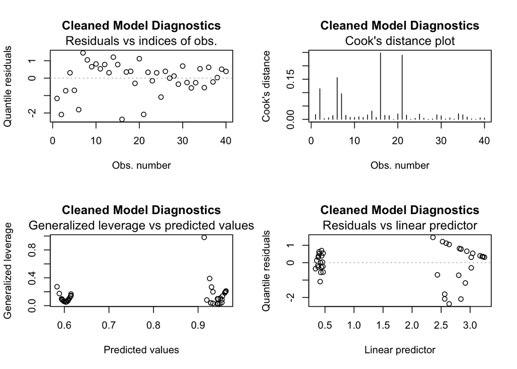

```r
par(mfrow = c(2, 2))
plot(model, main = "Cleaned Model Diagnostics")
```

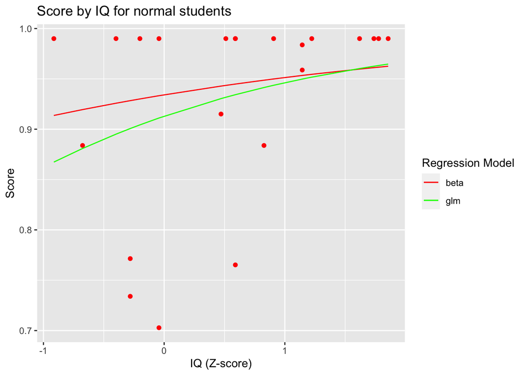

```r
dyslexiaModel <- ReadingSkillsModel.cleaned %>% filter(dyslexia == "yes")
normalModel <- ReadingSkillsModel.cleaned %>% filter(dyslexia == "no")

ggplot() + geom_point(aes(x=normalModel$iq, y=normalModel$accuracy), color="red") +
geom_line(aes(x=normalModel$iq, y=predict(model, newdata=normalModel), color="beta")) +
geom_line(aes(x=normalModel$iq, y=plogis(predict(linmodel, newdata=normalModel)), color="glm")) +
xlab("IQ (Z-score)") + ylab("Score") + ggtitle("Score by IQ for normal students") +
scale_color_manual(name="Regression Model", breaks=c("beta", "glm"), values=c("beta"="red", "glm"="green"))
```

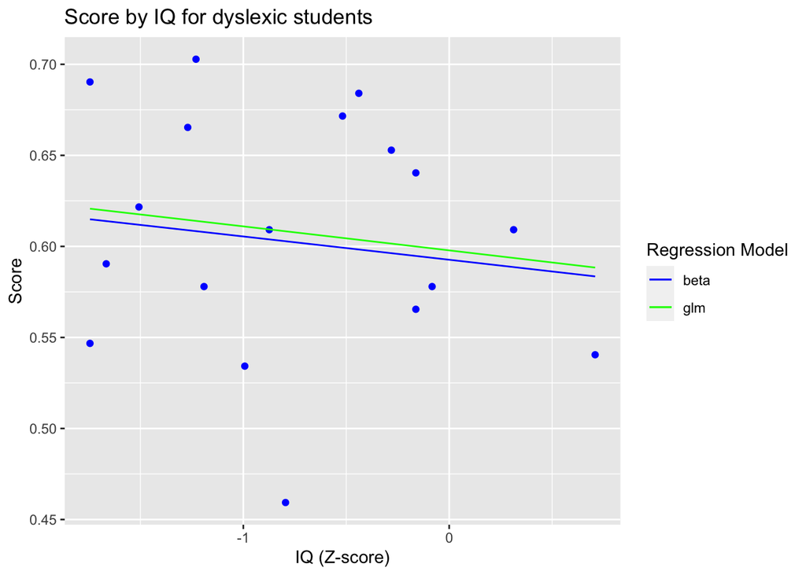

```r
ggplot() + geom_point(aes(x=dyslexiaModel$iq, y=dyslexiaModel$accuracy), color="blue") +
geom_line(aes(x=dyslexiaModel$iq, y=predict(model, newdata=dyslexiaModel), color="beta")) +
geom_line(aes(x=dyslexiaModel$iq, y=plogis(predict(linmodel, newdata=dyslexiaModel)), color="glm")) +
xlab("IQ (Z-score)") + ylab("Score") + ggtitle("Score by IQ for dyslexic students") +
scale_color_manual(name="Regression Model", breaks=c("beta", "glm"), values=c("beta"="blue", "glm"="green"))
```

We cleaned the dataset of possible outliers before fitting our final model. We considered a point an outlier if it has a cooks distance of more than 4 / N (in our case 4 / 44) or a leverage of more than 2*(the number of coefficients in the model) / N or a residual of more than 3 standard deviations. We found 4 such points.

## Results

```r
model.summary <- summary(model)
linmodel.summary <- summary(linmodel)

model.coefs <- model.summary$coefficients$mean
linmodel.coefs <- linmodel.summary$coefficients
```

| Table 2: Association of Reading Skills Score with IQ and presence of Dyslexia | Table 2: Association of Reading Skills Score with IQ and presence of Dyslexia | Table 2: Association of Reading Skills Score with IQ and presence of Dyslexia | Table 2: Association of Reading Skills Score with IQ and presence of Dyslexia | Table 2: Association of Reading Skills Score with IQ and presence of Dyslexia | Table 2: Association of Reading Skills Score with IQ and presence of Dyslexia | Table 2: Association of Reading Skills Score with IQ and presence of Dyslexia |  |  |  |  |  |  |  |
| --- | --- | --- | --- | --- | --- | --- | --- | --- | --- | --- | --- | --- | --- |
|  |  |  |  |  |  |  | Variable | Beta Regression |  |  | General Linear Regression |  |  |
| β | SE | p | β | SE | p |  |  |  |  |  |  |  |  |
| Dyslexia | -2.277 | 0.2942 | 9.86e-15 | -1.953 | 0.2793 | 3.333e-08 |  |  |  |  |  |  |  |
| IQ (Z-score) | 0.3205 | 0.2279 | 0.1597 | 0.5163 | 0.355 | 0.1545 |  |  |  |  |  |  |  |
| Dyslexia:iq | -0.3737 | 0.2885 | 0.1952 | -0.5714 | 0.3734 | 0.1347 |  |  |  |  |  |  |  |

Both the beta regression model and the general linear model with a logit link function show that whether or not a child has dyslexia significantly affects their reading skills score. In the beta regression model, the beta value of -2.277 means that for children with an average IQ, if they are dyslexic their odds of answering a reading question correctly decreases by a factor of $e^{2.277}$. IQ is a less significant with a p value of 0.1597 in the beta regression model and a p value of 0.1545 in the general linear model with a logit link function. Dyslexia:iq has similar significance to IQ alone. Both models show that for normal children, the higher the IQ the better their reading score. In the beta regression model, the beta value of 0.3205 means that for normal children, if IQ increases by 1 standard deviation then they their odds of answering a reading question correctly increases by a factor of $e^{0.3205}$. Both models show that for dyslexic children, higher IQs may hurt reading scores. In the beta regression model, the beta for dyslexia:iq is -0.3737. This means that for dyslexic children, the effective beta for IQ is 0.3205 - 0.3737 = -0.0532. This means that for a dyslexic child, if their IQ increases by 1 standard deviation, there odds of answering a reading question correctly decreases by a factor of $e^{0.0532}$

## Conclusion

In conclusion, beta regression is good to use when the dependent variable has a definite lower and upper bound such as a ratio or percentage. In the ReadingSkills dataset, both beta regression and normal linear regression with logit link show that in normal students as IQ goes up so do reading scores, but for dyslexic children, higher IQ generally means a slightly lower reading score.

```r
# loading packages
library(tidyverse)
library(knitr)
library(ggthemes)
library(ggrepel)
library(dslabs)
```

## References

[1]

N. J. Kutner M. Nachtsheim C., *Applied linear regression models*, 4th ed. New York, NY: McGraw-Hill, 2004.

[2]

D. D. Wackerly, *Mathematical statistics with applications*, 6th ed. Duxbury Press, 2002.

[3]

S. Ferrari and F. Cribari-Neto, “Beta regression for modelling rates and proportions,” *J. Appl. Stat.*, vol. 31, no. 7, pp. 799–815, Aug. 2004, doi: 10.1080/0266476042000214501.

[4]

B. Grün, I. Kosmidis, and A. Zeileis, “Extended beta regression in R: Shaken, stirred, mixed, and partitioned,” *Journal of Statistical Software*, vol. 48, no. 11, pp. 1–25, 2012, doi: 10.18637/jss.v048.i11.

[5]

M. Smithson and J. Verkuilen, “A better lemon squeezer? Maximum-likelihood regression with beta-distributed dependent variables,” *Psychol. Methods*, vol. 11, no. 1, pp. 54–71, Mar. 2006, doi: 10.1037/1082-989X.11.1.54.

[6]

F. Cribari-Neto and A. Zeileis, “Beta regression in R,” *Journal of Statistical Software*, vol. 34, no. 2, pp. 1–24, 2010, doi: 10.18637/jss.v034.i02.

[7]

R Core Team, *R: A language and environment for statistical computing*. Vienna, Austria: R Foundation for Statistical Computing, 2021. Available: https://www.R-project.org